# 富集分析可视化

Wenli Zhou

8-12-2021

### 环境搭建

```r
library(ggplot2)
library(org.Hs.eg.db)
library(clusterProfiler)
```

### 一、准备数据

##### 1. 导入所有的潜在的差异基因

```r
rm(list = ls())
download.file("https://cdn.jsdelivr.net/gh/lily123920/figures@main/uPic/degs_t_test%E7%9A%84%E5%89%AF%E6%9C%AC.csv",
              destfile = "degs_t_test.csv")
degs <- read.csv("degs_t_test.csv", header = T)
degs <- textshape::column_to_rownames(degs)
head(degs)
```

```
##               p_val avg_log2FC pct.1 pct.2     p_val_adj
## CCL5  6.702040e-193   2.714268 0.725 0.120 1.427266e-188
## LDHB  1.418228e-168  -1.585190 0.511 0.924 3.020259e-164
## GZMA  4.844229e-168   2.602722 0.687 0.132 1.031627e-163
## LTB   1.843616e-158  -1.476611 0.510 0.921 3.926166e-154
## EIF3E 5.620325e-144  -1.431147 0.524 0.900 1.196904e-139
## NPM1  3.966687e-142  -1.415790 0.649 0.954 8.447456e-138
```

##### 2. 根据阈值筛选DEGs

不同阈值筛选的DEGs的个数是不同的。 首先，确定阈值，筛选到合适个数的DEGs; 然后，确定下调和上调基因。。。 这里，up为疾病组上调，命名为genes_up; down为对照组相对上调，命名为genes_down.

```r
p_val_adj <- 0.05
degs_q <- degs[degs$p_val_adj < p_val_adj,]
genes_up <- rownames(degs_q)[degs_q$avg_log2FC > 0]
genes_down <- rownames(degs_q)[degs_q$avg_log2FC < 0]
genes_up[1:4]; genes_down[1:4]
```

```
## [1] "CCL5" "GZMA" "GZMK" "CST7"
```

```
## [1] "LDHB"  "LTB"   "EIF3E" "NPM1"
```

小结：进行KEGG和GO富集分析，只需要得到基因集列表（不需要任何和表达相关的信息）即可。

##### 3. ID转化

得到基因名称列表后，需要将其转换成entrezID才可以。

```r
library(org.Hs.eg.db)
library(clusterProfiler)
entrezid_up <- bitr(genes_up, "SYMBOL", "ENTREZID", "org.Hs.eg.db")
entrezid_down <- bitr(genes_down, "SYMBOL", "ENTREZID", "org.Hs.eg.db")
entrez_up <- entrezid_up$ENTREZID
entrez_down <- entrezid_down$ENTREZID
#entrezList <- list(entrez_pbmc, entrez_pla)
```

```r
entrez_up[1:4];entrez_down[1:4]
```

```
## [1] "6352" "3001" "3003" "8530"
```

```
## [1] "3945" "4050" "3646" "4869"
```

### 二、GO富集分析

GO富集分析的本质是超几何检验。。。 影响GO富集分析结果的输入包括：使用的数据库。

```r
# GO <- enrichGO(
#   entrez_up, keyType = "ENTREZID",
#   OrgDb='org.Hs.eg.db',
#   ont = "ALL", # 使用哪个条目进行注释，GO数据库有三个条目，分别是MF,BP,CC.
#   pvalueCutoff = 0.05,
#   pAdjustMethod = "BH", qvalueCutoff = 0.2,
#   #universe,
#   #minGSSize = 10,maxGSSize = 500,
#   readable = TRUE, # 输出结果中会直接将ENTREZID转换为SYMBOL
#   pool = FALSE
# )
# save(GO, file = "genes_up_GO.RData")
download.file("https://cdn.jsdelivr.net/gh/lily123920/figures@main/uPic/genes_up_GO.RData", destfile = "genes_up_GO.RData")
load("genes_up_GO.RData")
```

### 三、富集分析结果可视化

##### 1. dotplot图

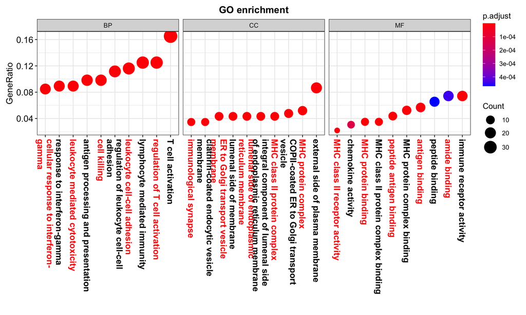

```r
# 确定配色
color = rep(c("red","black"),15)
# 确定美学主题
theme_customized = theme(plot.margin = unit(c(3, 3, 10, 3), "mm"),
                plot.title = element_text(hjust = 0.5, face = "bold"),
                axis.text.x = element_text(angle = -90,hjust = 0,vjust = 0.5,
                                     color = color,
                                     face = "bold"))
# 开始绘图
dot_GO <- dotplot(GO,x="GeneRatio",showCategory=10,
                    font.size=12,title="GO enrichment",
                    split = "ONTOLOGY" ) + coord_flip() +
          facet_grid(cols = vars(ONTOLOGY), scale="free") +
          scale_y_discrete(labels=function(y) stringr::str_wrap(y,width=36)) +
          theme_customized
dot_GO
```

##### 2. cne图

这张图主要是看通路之间交集的基因。。。。 如果一些基因介导了多条被富集到的通路，那么该基因可能会存在潜在的生物学效应。

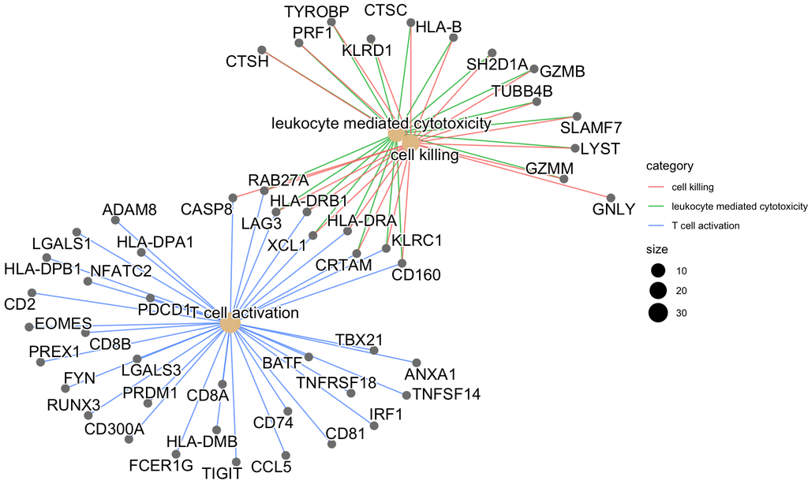

相同的颜色总是对应相同的数值

```r
library(ggnewscale)
cne_GO <- cnetplot(GO, foldChange=genes_up, categorySize="pvalue",
                     showCategory = 3, colorEdge = TRUE)
cne_GO
```

##### 3. 热图

这个图的作用同前，主要是为了chec基因在富集到的通路中出现的频次。

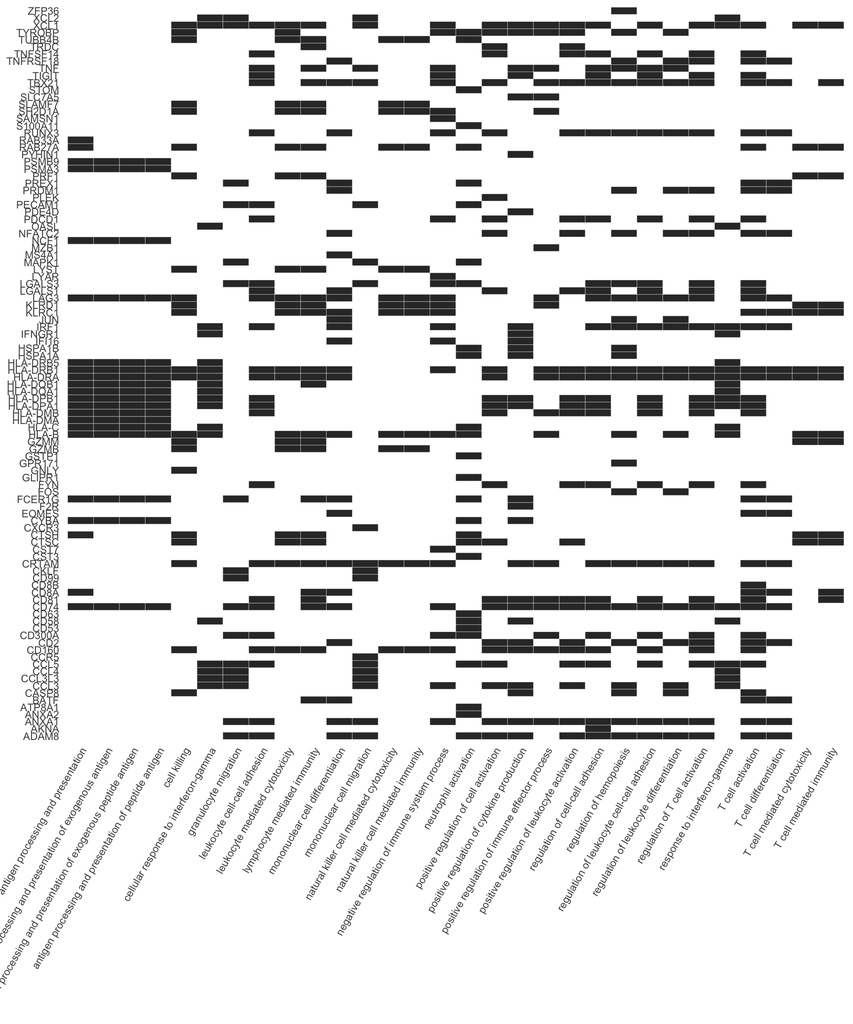

相同的颜色总是对应相同的数值

```r
heat_GO <- heatplot(GO) + coord_flip()
heat_GO
```

##### 4. 统计每个基因出现的频次，并绘图

```r
my_data <- GO@result[GO@result$Count >= 20,]
genelist <- my_data$geneID %>%
  stringr::str_split(., "/") %>%
  unlist() %>%
  table() %>%
  as.data.frame()
genelist <- genelist[order(genelist$Freq,decreasing = T),]
head(genelist)
```

```
##           . Freq
## 54 HLA-DRB1   28
## 53  HLA-DRA   24
## 20     CD74   23
## 1     ADAM8   21
## 3     ANXA1   20
## 14    CD160   20
```

```r
colnames(genelist) <- c("gene","Freq")

genelist$gene1 <- factor(genelist$gene, levels = genelist$gene)
str(genelist)
```

```
## 'data.frame':    109 obs. of  3 variables:
##  $ gene : Factor w/ 109 levels "ADAM8","AKNA",..: 54 53 20 1 3 14 25 65 106 21 ...
##  $ Freq : int  28 24 23 21 20 20 19 19 19 18 ...
##  $ gene1: Factor w/ 109 levels "HLA-DRB1","HLA-DRA",..: 1 2 3 4 5 6 7 8 9 10 ...
```

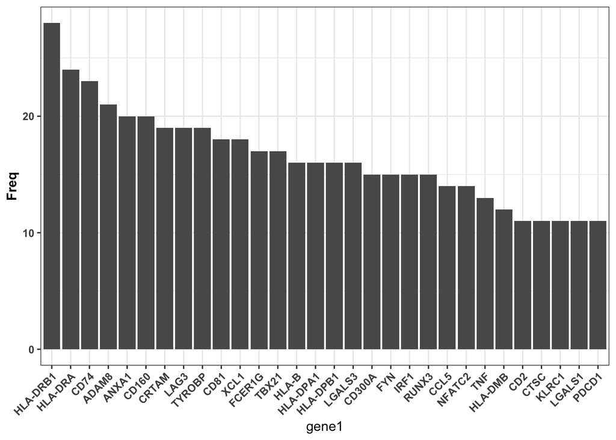

```r
  p <- ggplot(genelist[1:30,], aes(x = gene1, y = Freq )) +
    geom_bar(stat = "identity") +
    theme_bw() +
    theme(axis.text.x = element_text(angle = 45, hjust = 1, face = "bold"),
          axis.title.y  = element_text( face = "bold"),
          axis.text.y  = element_text( face = "bold"))
  p
```

### 四、KEGG富集分析

```r
kegg <- enrichKEGG(
  entrez_up, keyType = "kegg",
  organism = "hsa",
  pvalueCutoff = 0.05, pAdjustMethod = "BH", qvalueCutoff = 0.2,
  # universe,
  minGSSize = 10,maxGSSize = 500,
  use_internal_data = FALSE
)
```

```
## Reading KEGG annotation online:
##
## Reading KEGG annotation online:
```

```r
kegg
```

```
## #
## # over-representation test
## #
## #...@organism     hsa
## #...@ontology     KEGG
## #...@keytype      kegg
## #...@gene     chr [1:238] "6352" "3001" "3003" "8530" "6351" "4818" "2353" "5552" "5996" ...
## #...pvalues adjusted by 'BH' with cutoff <0.05
## #...53 enriched terms found
## 'data.frame':    53 obs. of  9 variables:
##  $ ID         : chr  "hsa05332" "hsa04612" "hsa05330" "hsa04940" ...
##  $ Description: chr  "Graft-versus-host disease" "Antigen processing and presentation" "Allograft rejection" "Type I diabetes mellitus" ...
##  $ GeneRatio  : chr  "16/133" "19/133" "14/133" "14/133" ...
##  $ BgRatio    : chr  "42/8096" "78/8096" "38/8096" "43/8096" ...
##  $ pvalue     : num  1.30e-18 9.98e-18 3.60e-16 2.72e-15 6.60e-14 ...
##  $ p.adjust   : num  2.82e-16 1.08e-15 2.60e-14 1.48e-13 2.86e-12 ...
##  $ qvalue     : num  2.11e-16 8.09e-16 1.95e-14 1.10e-13 2.14e-12 ...
##  $ geneID     : chr  "3824/5551/3123/3113/3127/3115/3122/3117/3821/3119/3108/3002/3109/7124/3106/3107" "925/972/3824/3123/3113/3127/3115/926/3304/3122/3117/3821/3119/3108/3109/7124/3303/3106/3107" "5551/3123/3113/3127/3115/3122/3117/3119/3108/3002/3109/7124/3106/3107" "5551/3123/3113/3127/3115/31…
##  $ Count      : int  16 19 14 14 16 17 14 11 13 19 ...
## #...Citation
##   Guangchuang Yu, Li-Gen Wang, Yanyan Han and Qing-Yu He.
##   clusterProfiler: an R package for comparing biological themes among
##   gene clusters. OMICS: A Journal of Integrative Biology
##   2012, 16(5):284-287
```

### 五、KEGG可视化

1. barplot图

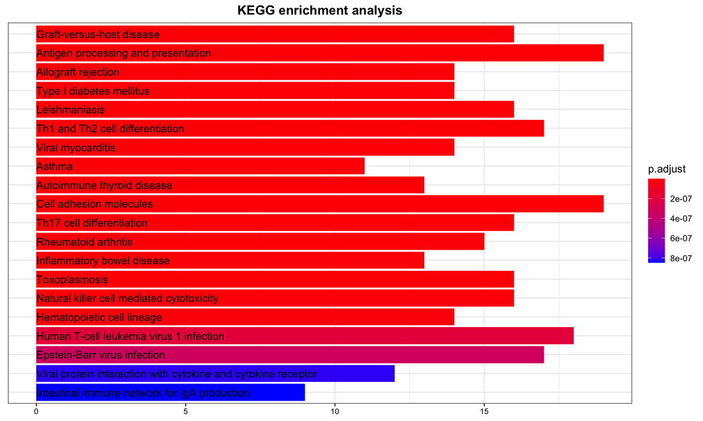

相同的颜色总是对应相同的数值

```r
# 确定配色

# 确定主题
theme_customized <- theme(
                          axis.text.y = element_blank(),
                          axis.ticks.y = element_blank(),
                          plot.title = element_text(hjust = 0.5, face = "bold"))
# 开始绘图
barplot_kegg <- graphics::barplot(kegg,
          drop = FALSE,
          showCategory = 20,
          title = "KEGG enrichment analysis",
          font.size = 8) +
    geom_text(aes(label = Description),x=0,hjust=0)+
    theme_customized
barplot_kegg
```

2. dotplot图

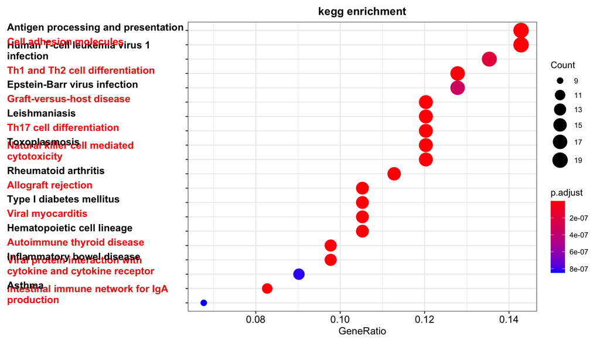

```r
# 确定配色
# 确定主题
theme_customized <- theme(plot.margin = unit(c(3, 3, 10, 3), "mm"),
                          plot.title = element_text(hjust = 0.5, face = "bold"),
                          axis.text.y = element_text(angle = 0,hjust = 0,vjust = 0,
                                                     color = rep(c("red","black"),15),
                                                    face = "bold"))
dot_kegg <- dotplot(kegg,x="GeneRatio",showCategory=20,
                    font.size=12,title="kegg enrichment") +
  theme_customized +
  scale_y_discrete(labels=function(y) stringr::str_wrap(y,width=36)) # 折叠纵坐标
dot_kegg
```

完结。。。 对于富集结果信息的挖掘，需要注意一点：上调基因和下调基因可能会富集到同一条通路哦。。。 这时候结果该怎么解读呢？其实同一条通路中的不同基因也会介导不同的功能的。 不管是KEGG还是GO富集分析，研究者所关注的是这些基因的功能。 富集分析的终点是对这些差异基因功能解读。 如何解读呢？ ①富集到某条通路，说明这条通路相关的功能确实是和该疾病状态相关的。 毕竟不同的疾病的DEGs富集到的通路是不同的。 ②一条通路中涉及的基因是有可能起着不同的作用的。。。所以下一步要筛选 感兴趣的通路，然后check富集到这些通路的基因具体起着什么样的作用。